# 🧹 Step 2 - Data Analysis and Visualization

## 📚 Course 4: Data Cleaning and Analysis

## 2️⃣ Combining Data With Pandas

👦 [Anh-Thi DINH](https://dinhanhthi.com) — 🔥 dataquest-aio on Github — 🌏 [Dataquest](https://dataquest.io/)

⚡ **Note**: Some errors in this notebook appear intentionally to illustrate the wrong commands.

❓ You run this notebook on Google Colab? If "Yes", please replace `0` by `1` in the below cell and run it first.

```python
use_colab = 0 # 1 if you use Google Colab to read/run this notebook
```

## 📝 Mission 344

⏬ Download the takeaway for this mission in folder `/takeaways/` [on Github](https://github.com/dinhanhthi/dataquest-aio/tree/master/takeaways). [Source](https://app.dataquest.io/m/344/combining-data-with-pandas) of this mission.

In previous tasks, we only work with 1 dataset. From this mission, we will **work with more than one dataset** at a time. It's very common in practice.

❓❓ **Question**: *Did world happiness increase, decrease, or stay about the same from 2015 to 2017?*

```python
import pandas as pd # import pandas package
import numpy as np

# show the plots inside the notebook
%matplotlib inline
```

```python
if use_colab:
    dataquest_aio = 'https://raw.githubusercontent.com/dinhanhthi/dataquest-aio/master/step-2-data-analysis-and-visualization/'
    dataset_2015_url = dataquest_aio + 'course-4-data-cleaning-and-analysis/data/World_Happiness_2015.csv'
    dataset_2016_url = dataquest_aio + 'course-4-data-cleaning-and-analysis/data/World_Happiness_2016.csv'
    dataset_2017_url = dataquest_aio + 'course-4-data-cleaning-and-analysis/data/World_Happiness_2017.csv'
else: # if you use localhost
    dataset_2015_url = './data/World_Happiness_2015.csv'
    dataset_2016_url = './data/World_Happiness_2016.csv'
    dataset_2017_url = './data/World_Happiness_2017.csv'
```

```python
# let's take a look on report of 2015
happiness2015 = pd.read_csv(dataset_2015_url)
happiness2015.head()
```

|  | Country | Region | Happiness Rank | Happiness Score | Standard Error | Economy (GDP per Capita) | Family | Health (Life Expectancy) | Freedom | Trust (Government Corruption) | Generosity | Dystopia Residual |
| --- | --- | --- | --- | --- | --- | --- | --- | --- | --- | --- | --- | --- |
| 0 | Switzerland | Western Europe | 1 | 7.587 | 0.03411 | 1.39651 | 1.34951 | 0.94143 | 0.66557 | 0.41978 | 0.29678 | 2.51738 |
| 1 | Iceland | Western Europe | 2 | 7.561 | 0.04884 | 1.30232 | 1.40223 | 0.94784 | 0.62877 | 0.14145 | 0.43630 | 2.70201 |
| 2 | Denmark | Western Europe | 3 | 7.527 | 0.03328 | 1.32548 | 1.36058 | 0.87464 | 0.64938 | 0.48357 | 0.34139 | 2.49204 |
| 3 | Norway | Western Europe | 4 | 7.522 | 0.03880 | 1.45900 | 1.33095 | 0.88521 | 0.66973 | 0.36503 | 0.34699 | 2.46531 |
| 4 | Canada | North America | 5 | 7.427 | 0.03553 | 1.32629 | 1.32261 | 0.90563 | 0.63297 | 0.32957 | 0.45811 | 2.45176 |

Recall the meaning of columns:

- `Country` - Name of the country.
- `Region` - Name of the region the country belongs to.
- `Happiness Rank` - The rank of the country, as determined by its happiness score.
- `Happiness Score` - A score assigned to each country based on the answers to a poll question that asks respondents to rate their happiness on a scale of 0-10.
- `Family` - The estimated extent to which family contributes to the happiness score.
- `Freedom` - The estimated extent to which freedom contributes to the happiness score.
- `Generosity` - The estimated extent to which generosity contributes to the happiness score.

```python
# read the data of 2016 and 2017
happiness2016 = pd.read_csv(dataset_2016_url)
happiness2017 = pd.read_csv(dataset_2017_url)
```

```python
happiness2016.head()
```

|  | Country | Region | Happiness Rank | Happiness Score | Lower Confidence Interval | Upper Confidence Interval | Economy (GDP per Capita) | Family | Health (Life Expectancy) | Freedom | Trust (Government Corruption) | Generosity | Dystopia Residual |
| --- | --- | --- | --- | --- | --- | --- | --- | --- | --- | --- | --- | --- | --- |
| 0 | Denmark | Western Europe | 1 | 7.526 | 7.460 | 7.592 | 1.44178 | 1.16374 | 0.79504 | 0.57941 | 0.44453 | 0.36171 | 2.73939 |
| 1 | Switzerland | Western Europe | 2 | 7.509 | 7.428 | 7.590 | 1.52733 | 1.14524 | 0.86303 | 0.58557 | 0.41203 | 0.28083 | 2.69463 |
| 2 | Iceland | Western Europe | 3 | 7.501 | 7.333 | 7.669 | 1.42666 | 1.18326 | 0.86733 | 0.56624 | 0.14975 | 0.47678 | 2.83137 |
| 3 | Norway | Western Europe | 4 | 7.498 | 7.421 | 7.575 | 1.57744 | 1.12690 | 0.79579 | 0.59609 | 0.35776 | 0.37895 | 2.66465 |
| 4 | Finland | Western Europe | 5 | 7.413 | 7.351 | 7.475 | 1.40598 | 1.13464 | 0.81091 | 0.57104 | 0.41004 | 0.25492 | 2.82596 |

```python
happiness2017.head()
```

|  | Country | Happiness.Rank | Happiness.Score | Whisker.high | Whisker.low | Economy..GDP.per.Capita. | Family | Health..Life.Expectancy. | Freedom | Generosity | Trust..Government.Corruption. | Dystopia.Residual |
| --- | --- | --- | --- | --- | --- | --- | --- | --- | --- | --- | --- | --- |
| 0 | Norway | 1 | 7.537 | 7.594445 | 7.479556 | 1.616463 | 1.533524 | 0.796667 | 0.635423 | 0.362012 | 0.315964 | 2.277027 |
| 1 | Denmark | 2 | 7.522 | 7.581728 | 7.462272 | 1.482383 | 1.551122 | 0.792566 | 0.626007 | 0.355280 | 0.400770 | 2.313707 |
| 2 | Iceland | 3 | 7.504 | 7.622030 | 7.385970 | 1.480633 | 1.610574 | 0.833552 | 0.627163 | 0.475540 | 0.153527 | 2.322715 |
| 3 | Switzerland | 4 | 7.494 | 7.561772 | 7.426227 | 1.564980 | 1.516912 | 0.858131 | 0.620071 | 0.290549 | 0.367007 | 2.276716 |
| 4 | Finland | 5 | 7.469 | 7.527542 | 7.410458 | 1.443572 | 1.540247 | 0.809158 | 0.617951 | 0.245483 | 0.382612 | 2.430182 |

There are a little differences on the columns' name of dataset 2017.

```python
# add column called "Year" whose values in all rows are the corresponding year to that dataframe
happiness2015['Year'] = 2015
happiness2016['Year'] = 2016
happiness2017['Year'] = 2017
```

## 👉 `pd.concat()` [function](https://pandas.pydata.org/pandas-docs/stable/generated/pandas.concat.html)

This function combines MULTIPLE dataframes 1 of 2 ways:

FIRST, **Stacked** (`axis=0`, default): They combines values in multiple dataframes with **the same columns** (columns are unique).

[figure not shown]

SECOND, **Side by side** (`axis=1`): They combines columns in multiple dataframes with **the same indexes** (indexes are unique).

[figure not shown]

```python
# Let's consider 2 different heads of 2015 and 2016 and then combine them into one dataframe
head_2015 = happiness2015[['Country','Happiness Score', 'Year']].head(3)
head_2016 = happiness2016[['Country','Happiness Score', 'Year']].head(3)

concat_axis0 = pd.concat([head_2015, head_2016])
concat_axis1 = pd.concat([head_2015, head_2016], axis=1)
```

```python
# Below codes are only for displaying multiple dataframes side-by-side, it's not a part of this lesson!
from IPython.display import display_html
def display_side_by_side(*args):
    html_str=''
    for df in args:
        html_str += df.to_html()
    display_html(html_str.replace('table','table style="display:inline"'), raw=True)
```

```python
display_side_by_side(head_2015, head_2016)
display_side_by_side(concat_axis0, concat_axis1)
```

|  | Country | Happiness Score | Year |
| --- | --- | --- | --- |
| 0 | Switzerland | 7.587 | 2015 |
| 1 | Iceland | 7.561 | 2015 |
| 2 | Denmark | 7.527 | 2015 |

|  | Country | Happiness Score | Year |
| --- | --- | --- | --- |
| 0 | Denmark | 7.526 | 2016 |
| 1 | Switzerland | 7.509 | 2016 |
| 2 | Iceland | 7.501 | 2016 |

|  | Country | Happiness Score | Year |
| --- | --- | --- | --- |
| 0 | Switzerland | 7.587 | 2015 |
| 1 | Iceland | 7.561 | 2015 |
| 2 | Denmark | 7.527 | 2015 |
| 0 | Denmark | 7.526 | 2016 |
| 1 | Switzerland | 7.509 | 2016 |
| 2 | Iceland | 7.501 | 2016 |

|  | Country | Happiness Score | Year | Country | Happiness Score | Year |
| --- | --- | --- | --- | --- | --- | --- |
| 0 | Switzerland | 7.587 | 2015 | Denmark | 7.526 | 2016 |
| 1 | Iceland | 7.561 | 2015 | Switzerland | 7.509 | 2016 |
| 2 | Denmark | 7.527 | 2015 | Iceland | 7.501 | 2016 |

❓ What if the dataframes have different shapes or columns?

```python
head_2015 = happiness2015[['Year','Country','Happiness Score', 'Standard Error']].head(4) # 4 columns
head_2016 = happiness2016[['Country','Happiness Score', 'Year']].head(3) # 3 columns

display_side_by_side(head_2015, head_2016)
```

|  | Year | Country | Happiness Score | Standard Error |
| --- | --- | --- | --- | --- |
| 0 | 2015 | Switzerland | 7.587 | 0.03411 |
| 1 | 2015 | Iceland | 7.561 | 0.04884 |
| 2 | 2015 | Denmark | 7.527 | 0.03328 |
| 3 | 2015 | Norway | 7.522 | 0.03880 |

|  | Country | Happiness Score | Year |
| --- | --- | --- | --- |
| 0 | Denmark | 7.526 | 2016 |
| 1 | Switzerland | 7.509 | 2016 |
| 2 | Iceland | 7.501 | 2016 |

```python
concat_axis0 = pd.concat([head_2015, head_2016], sort=True) # axis=0
concat_axis1 = pd.concat([head_2015, head_2016], axis=1) # axis=1

display_side_by_side(concat_axis0, concat_axis1)
```

|  | Country | Happiness Score | Standard Error | Year |
| --- | --- | --- | --- | --- |
| 0 | Switzerland | 7.587 | 0.03411 | 2015 |
| 1 | Iceland | 7.561 | 0.04884 | 2015 |
| 2 | Denmark | 7.527 | 0.03328 | 2015 |
| 3 | Norway | 7.522 | 0.03880 | 2015 |
| 0 | Denmark | 7.526 | NaN | 2016 |
| 1 | Switzerland | 7.509 | NaN | 2016 |
| 2 | Iceland | 7.501 | NaN | 2016 |

|  | Year | Country | Happiness Score | Standard Error | Country | Happiness Score | Year |
| --- | --- | --- | --- | --- | --- | --- | --- |
| 0 | 2015 | Switzerland | 7.587 | 0.03411 | Denmark | 7.526 | 2016.0 |
| 1 | 2015 | Iceland | 7.561 | 0.04884 | Switzerland | 7.509 | 2016.0 |
| 2 | 2015 | Denmark | 7.527 | 0.03328 | Iceland | 7.501 | 2016.0 |
| 3 | 2015 | Norway | 7.522 | 0.03880 | NaN | NaN | NaN |

⭐ Some comments:

- Because the `Standard Error` column didn't exist in `head_2016`, `NaN` values were created to signify those values are missing.
- The `concat` function will keep ALL of the data, no matter if missing values are created.
- The indexes of the original dataframes didn't change.

❓ It looks like the indexes in the case `axis=0` duplicates. It could cause errors as we perform other data cleaning tasks. Can we reset the indexes?

💡 Yep! Using parameter `ignore_index=True`.

```python
pd.concat([head_2015, head_2016], ignore_index=True, sort=True)
```

|  | Country | Happiness Score | Standard Error | Year |
| --- | --- | --- | --- | --- |
| 0 | Switzerland | 7.587 | 0.03411 | 2015 |
| 1 | Iceland | 7.561 | 0.04884 | 2015 |
| 2 | Denmark | 7.527 | 0.03328 | 2015 |
| 3 | Norway | 7.522 | 0.03880 | 2015 |
| 4 | Denmark | 7.526 | NaN | 2016 |
| 5 | Switzerland | 7.509 | NaN | 2016 |
| 6 | Iceland | 7.501 | NaN | 2016 |

## 👉 `pd.merge()` [function](https://pandas.pydata.org/pandas-docs/stable/generated/pandas.DataFrame.merge.html)

- The `merge` function ONLY combines dataframes horizontally (`axis=1`).
- It can only combine TWO dataframes at a time.
- Combine dataframes on a **key**. It's good practice to use keys with unique values to avoid duplicating data.

[figure not shown]

```python
# Let's consider 2 different parts of 2 datasets
three_2015 = happiness2015[['Country','Happiness Rank','Year']].iloc[2:5]
three_2016 = happiness2016[['Country','Happiness Rank','Year']].iloc[2:5]

# apply merge
merged = pd.merge(left=three_2015, right=three_2016, on='Country')
```

```python
display_side_by_side(three_2015, three_2016)
display(merged)
```

|  | Country | Happiness Rank | Year |
| --- | --- | --- | --- |
| 2 | Denmark | 3 | 2015 |
| 3 | Norway | 4 | 2015 |
| 4 | Canada | 5 | 2015 |

|  | Country | Happiness Rank | Year |
| --- | --- | --- | --- |
| 2 | Iceland | 3 | 2016 |
| 3 | Norway | 4 | 2016 |
| 4 | Finland | 5 | 2016 |

|  | Country | Happiness Rank_x | Year_x | Happiness Rank_y | Year_y |
| --- | --- | --- | --- | --- | --- |
| 0 | Norway | 4 | 2015 | 4 | 2016 |

⭐ We see that the key in this case is the column `Country`. There is only 1 common value (`Norway`) in 2 dataframes so the `merged` only has 1 row. This way of *joining* data is called **INNER JOIN**.

Beside **inner join**, we also have other types of joining (they come from [SQL](https://www.w3schools.com/sql/sql_join.asp)):

- **Inner**: only includes elements that appear in both dataframes with a common key.
- **Outer**: includes all data from both dataframes.
- **Left**: includes all of the rows from the "left" dataframe along with any rows from the "right" dataframe with a common key; the result retains all columns from both of the original dataframes.
- **Right**: includes all of the rows from the "right" dataframe along with any rows from the "left" dataframe with a common key; the result retains all columns from both of the original dataframes.

An example of **outer join** is the case of using `concat` above.

```python
# try with left join
merged_left = pd.merge(left=three_2015, right=three_2016, how='left', on='Country')

# change the order of three_2015 and three_2016
merged_left_updated = pd.merge(left=three_2016, right=three_2015, how='left', on='Country')

display_side_by_side(three_2015, three_2016)
display_side_by_side(merged_left, merged_left_updated)
```

|  | Country | Happiness Rank | Year |
| --- | --- | --- | --- |
| 2 | Denmark | 3 | 2015 |
| 3 | Norway | 4 | 2015 |
| 4 | Canada | 5 | 2015 |

|  | Country | Happiness Rank | Year |
| --- | --- | --- | --- |
| 2 | Iceland | 3 | 2016 |
| 3 | Norway | 4 | 2016 |
| 4 | Finland | 5 | 2016 |

|  | Country | Happiness Rank_x | Year_x | Happiness Rank_y | Year_y |
| --- | --- | --- | --- | --- | --- |
| 0 | Denmark | 3 | 2015 | NaN | NaN |
| 1 | Norway | 4 | 2015 | 4.0 | 2016.0 |
| 2 | Canada | 5 | 2015 | NaN | NaN |

|  | Country | Happiness Rank_x | Year_x | Happiness Rank_y | Year_y |
| --- | --- | --- | --- | --- | --- |
| 0 | Iceland | 3 | 2016 | NaN | NaN |
| 1 | Norway | 4 | 2016 | 4.0 | 2015.0 |
| 2 | Finland | 5 | 2016 | NaN | NaN |

On the case of `merged_left` (`three_2015` is the main), we keep all key values of `three_2015` and take corresponding rows from `three_2016` for merging. Therefore, some rows in `three_2016` are not kept (`Iceland`, `Findland`). We help the contrary in the case of `merged_updated` where `three_2016` is the main.

❓ Note that, the suffixes `_x`, `_y` are automatically added to the columns to separate them. Can we change them to our custom name?

💡 Of course, use parameter `suffixes`!

```python
pd.merge(left=three_2015, right=three_2016, how='left', on='Country', suffixes=('_2015', '_2016'))
```

|  | Country | Happiness Rank_2015 | Year_2015 | Happiness Rank_2016 | Year_2016 |
| --- | --- | --- | --- | --- | --- |
| 0 | Denmark | 3 | 2015 | NaN | NaN |
| 1 | Norway | 4 | 2015 | 4.0 | 2016.0 |
| 2 | Canada | 5 | 2015 | NaN | NaN |

⭐ Now, we take the inner join again but **with the index** that time. Let's see what happens?

```python
four_2015 = happiness2015[['Country','Happiness Rank','Year']].iloc[2:6]
three_2016 = happiness2016[['Country','Happiness Rank','Year']].iloc[2:5]

display_side_by_side(four_2015, three_2016)
```

|  | Country | Happiness Rank | Year |
| --- | --- | --- | --- |
| 2 | Denmark | 3 | 2015 |
| 3 | Norway | 4 | 2015 |
| 4 | Canada | 5 | 2015 |
| 5 | Finland | 6 | 2015 |

|  | Country | Happiness Rank | Year |
| --- | --- | --- | --- |
| 2 | Iceland | 3 | 2016 |
| 3 | Norway | 4 | 2016 |
| 4 | Finland | 5 | 2016 |

```python
pd.merge(left=four_2015, right=three_2016, left_index=True, right_index=True, suffixes=('_2015','_2016'))
```

|  | Country_2015 | Happiness Rank_2015 | Year_2015 | Country_2016 | Happiness Rank_2016 | Year_2016 |
| --- | --- | --- | --- | --- | --- | --- |
| 2 | Denmark | 3 | 2015 | Iceland | 3 | 2016 |
| 3 | Norway | 4 | 2015 | Norway | 4 | 2016 |
| 4 | Canada | 5 | 2015 | Finland | 5 | 2016 |

```python
pd.merge(left=four_2015, right=three_2016, how='left', left_index=True, right_index=True, suffixes=('_2015','_2016'))
```

|  | Country_2015 | Happiness Rank_2015 | Year_2015 | Country_2016 | Happiness Rank_2016 | Year_2016 |
| --- | --- | --- | --- | --- | --- | --- |
| 2 | Denmark | 3 | 2015 | Iceland | 3.0 | 2016.0 |
| 3 | Norway | 4 | 2015 | Norway | 4.0 | 2016.0 |
| 4 | Canada | 5 | 2015 | Finland | 5.0 | 2016.0 |
| 5 | Finland | 6 | 2015 | NaN | NaN | NaN |

❓❓ **Question**: Did world happiness increase, decrease, or stay about the same from 2015 to 2017?

```python
# rememeber the names of columns in 2007 are fifference? We change only 1 column
happiness2017.rename(columns={'Happiness.Score': 'Happiness Score'}, inplace=True)

# combine 2 dataframes
combined = pd.concat([happiness2015, happiness2016, happiness2017], sort=False)
pivot_table_combined = combined.pivot_table(index='Year', values='Happiness Score', aggfunc=np.mean)
pivot_table_combined
```

| Year | Happiness Score |
| --- | --- |
| 2015 | 5.375734 |
| 2016 | 5.382185 |
| 2017 | 5.354019 |

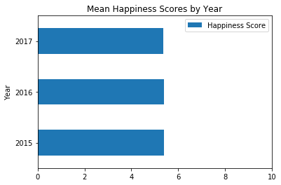

```python
# plot
pivot_table_combined.plot(kind='barh', title='Mean Happiness Scores by Year', xlim=(0,10))
```

💡 The happiness stayed approximately the same from 2015 to 2017.

👉 **Futher reading**: [Merge, join, and concatenate](https://pandas.pydata.org/pandas-docs/stable/user_guide/merging.html#merge-join-and-concatenate).